# 0. PREPARATION (Etat : 100% Terminé)

## 0.1. Importations

Ci-dessous l'ensemble des librairies utilisées pour toute l'étude

```python
# Pour rendre les fichiers Excels exploitables après téléchargement
import os
import re                                # Module d'opérations à base d'expressions rationnelles
import shutil                            # Module High-level file operations
import tempfile                          # Module de génération de fichiers et répertoires temporaires
from fnmatch      import fnmatch         # Librairie de filtrage par motif des noms de fichiers UNIX
from os           import listdir         # Pour lister les fichiers et sous-dossiers existants dans un répertoire
from os.path      import isfile, join    # Manipulation des noms de répertoires communs
from zipfile      import ZipFile         # Manipulation des fichiers ZIP

# Pour pré-traiter, traiter, et post-traiter les données
import cartopy as ctp                               # Pour manipuler les données géographiques
import datetime as dt                               # Pour manipuler les données temporelles
import dateparser
import matplotlib.pyplot as plt                     # Pour représenter les données
import locale
import numpy as np                                  # Pour manipuler les données
import pandas as pd                                 # Pour manipuler les données en forme de DataFrame
import requests                                     # Pour récupérer les données HTTP
import seaborn as sns
import sklearn
import unidecode

from bs4 import BeautifulSoup                       # Pour exploiter les données d'un site internet à base de code HTML
from sklearn.metrics import r2_score                #
from sklearn import preprocessing                   #
from sklearn.linear_model import LassoCV            #
from sklearn.linear_model import LinearRegression   # Pour études de régression linéaire

# Pour analyser et optimiser le temps de traitement
import time
import threading
from tqdm.auto import tqdm
```

## 0.2. Définitions des répertoires, liens internet, et type de fichiers

Les principaux liens, tels :

- Le répertoire principal
- Le dossier où sont stockés les fichiers Excel de classement
- Les liens internet de chargement de données

```python
# Directories & SubDirectories
DIR_Main = os.getcwd()        # Main directory
DIR_XLSRank = 'DataRank_2021' # Sub-directory containing xlsx daily rank files

#DataSkipperDir = 'DataSkipper_2021'

# Uniform Resource Locators (URL) of Vendee Globe 2020-2021 data
URL_Ranks = "https://www.vendeeglobe.org/fr/classement"
URL_DwnldRank = "https://www.vendeeglobe.org/download-race-data/vendeeglobe_"
URL_Skippers = "https://www.vendeeglobe.org/fr/glossaire"

# FilesType
EXT_RankFile = ".xlsx"
```

## 0.3. Outils de conversion

Cette fonction va permettre de convertir les dates d'enregistrement extraites du site internet. Elles vont servir essentiellement:

- pour le téléchargement de tous les fichiers
- localiser temporellement chaque ligne appartenant à un voilier spécifique dans ledataframe

```python
def CONVERT_TIME_FORMAT (LIST_URL_Time :'YYYY-MM-DD hh:mm:ss')\
      ->'datetime.datetime(YYYY,M,D,H,M),[YYYYMMDD_HHMMSS]':

    LIST_Time =[]               # Daily rank date list extracted from URL_Rank
    LIST_FileID = []            # File ID list
    for i in LIST_URL_Time:     # Converting all the daily rank date formats
        LIST_Time.append(dt.datetime.strptime(i, "%Y-%m-%d %H:%M:%S"))
        LIST_FileID.append(dt.datetime.strptime(i, "%Y-%m-%d %H:%M:%S").
                           strftime("%Y%m%d_%H%M%S"))
    return LIST_Time,LIST_FileID
```

## 0.4. Gestion des répertoires et des fichiers

Ci-dessous, un ensemble de code permettant la gestion des fichiers et des répertoires. Notamment:

### La vérification de l'existance des dossier

> Note: Le booléen en sortie de cette fonction, permet à une autre fonction de confirmer l'existance du dossier

```python
def CHECK_DATA_DIR(DIR_Main:'Dir_String', TYPE_Data:'Type_String')\
      ->'BOOL_ExistDir, DIR_Data':

    DIR_Data = os.path.join(DIR_Main, TYPE_Data)
    if not os.path.exists(DIR_Data):   # Make subdirectory if doesn't exist
        os.mkdir(DIR_Data)
        BOOL_DirExist = False
    else:
        BOOL_DirExist = True           # Else pass
    print("The subdirectory exists "+TYPE_Data+" exists :"+\
          str(np.where(BOOL_DirExist==True,"OK","NOK")))
    return BOOL_DirExist, DIR_Data
```

### L'obtention d'une liste avec toutes les dates d'enregistrement

> Cette liste permet aussi d'identifier le nom et la date du fichier

```python
def GET_RANKING_DATE_LIST(URL_Ranks : 'URL_String')\
      ->'List of ranking date in AAAA-MM-DD HH:MM:SS format':


    SOUP_URLRank = BeautifulSoup(requests.get(URL_Ranks).
                                 content.decode('utf-8'))            #Get Soup
    LIST_SoupURLRank = SOUP_URLRank\
          .findAll('option')                        #Extract only options list
    LIST_RankDate = []
    for iLIST_SoupURLRank in LIST_SoupURLRank:     #Generate ranking date list
        LIST_RankDate.append(iLIST_SoupURLRank.text[2:])
    LIST_RankDate = np.unique(LIST_RankDate[1:-1])        #Delete duplications
    print("Number of daily ranking files : " + str(len(LIST_RankDate)))
    return LIST_RankDate
```

### La mise à jour des fichiers une fois téléchargés

> Les fichiers excel ont posé problème lors de l'ouverture avec pd.read_excel. Nous avons besoin de passer par ce code pour y remédier.

```python
def UPDATE_FORMAT(FILE : "FileName.FileExt string",
                  name_filter : "Name filer string",
                  change : 'string')\
      ->'Nothing : Excel files are updated to be workable':
    DIR_temp = tempfile.mkdtemp()
    try:
        NAME_temp = os.path.join(DIR_temp, 'new.zip')
        with ZipFile(FILE, 'r') as r, ZipFile(NAME_temp, 'w') as w:
            for item in r.infolist():
                DATA = r.read(item.filename)
                DATA = change(DATA)
                w.writestr(item, DATA)
        shutil.move(NAME_temp, FILE)
    finally:
        shutil.rmtree(DIR_temp)
```

### Le téléchargement des fichiers Excel

```python
def DWNLD_DAILY_RANK_FILES(URL_DwnldRank : 'DownloadingURL_String',
                           LIST_FileID : 'List of string containing files ID',
                           EXT_RankFile : '.ext_file String',
                           DIR_Data : 'Data Directory string',
                           DIR_Main : 'Main Directory string')\
      -> 'Nothing : Excel files downloaded and saved in data directory':
    os.chdir(DIR_Data)                                    # Go to subdirectory
    with tqdm(range(len(LIST_FileID)),
              desc = "Downloading progress bar")\
              as outer :
        for iLIST_FileID in LIST_FileID:    # Download each Excel ranking file
            resp = requests.get(URL_DwnldRank+iLIST_FileID+EXT_RankFile)
            FILE = "vendeeglobe_"+iLIST_FileID+EXT_RankFile
            with open(FILE,'wb')as file:
                file.write(resp.content)
            UPDATE_FORMAT(FILE,name_filter='xl/styles.xml',
                          change=lambda d:re.sub(b'xxid="\d*"',b"",d))
            outer.update()
    os.chdir(DIR_Main)
```

### La vérification de l'existance de tous les fichiers nécessaires

```python
def CHECK_FILE_LIST(DIR_Main: 'Main directory string',
                    DIR_Data: 'Ranking excel directory string',
                    LIST_FileID: 'List of excel file ID string')\
      -> 'List of string of excel file ID to download':
    LIST_FilesTemp = [f for f in listdir(DIR_Data)\
                      if isfile(join(DIR_Data,f))]
    LIST_FilesToDwnld = []
    for iLIST_FilesTemp in LIST_FileID:
        if not str("vendeeglobe_"+iLIST_FilesTemp+".xlsx") in LIST_FilesTemp:
            LIST_FilesToDwnld.append(iLIST_FilesTemp)
    return LIST_FilesToDwnld
```

## 0.5. Main de lancement de la phase d'initialisation

C'est ici que le programme exécute l'ensemble des fonctions mentionnés précédemment. Il va d'abord vérifier l'existence des répertoires. Si celui-ci existe, il va vérifier si oui ou non des fichiers manquent. Dans le cas d'un manque de certains fichiers, celui-ci va les télécharger. Dans le cas où le dossier n'existe pas, le programme va d'abord créer le dossier puis télécharger tous les fichiers.

```python
'''MAIN DOWNLOADING DATA'''

BOOL_DirExist, DIR_Data = CHECK_DATA_DIR(DIR_Main,DIR_XLSRank)
LIST_RankDate = GET_RANKING_DATE_LIST(URL_Ranks)
LIST_Time, LIST_FileID = CONVERT_TIME_FORMAT(LIST_RankDate)
"""if BOOL_DirExist == False:
    print('Subdirectory "Datarank_2021" complete : NOK')
    print('Downloading ', len(LIST_FileID),
          ' Excel daily ranking files')
    DWNLD_DAILY_RANK_FILES(URL_DwnldRank,
                           LIST_FileID,
                           EXT_RankFile,
                           DIR_Data,
                           DIR_Main)
else :"""
LIST_FilesToDwnld = CHECK_FILE_LIST(DIR_Main,
                                    DIR_Data,
                                    LIST_FileID)
if len(LIST_FilesToDwnld)!=0:
    print('Subdirectory "Datarank_2021" complete : NOK')
    print('Downloading ',len(LIST_FilesToDwnld),
          ' missing Excel daily ranking files')
    DWNLD_DAILY_RANK_FILES(URL_DwnldRank,
                          LIST_FilesToDwnld,
                          EXT_RankFile,
                          DIR_Data,
                          DIR_Main)

print("-------------------------------------------------")
print('Subdirectory "Datarank_2021" created : OK')
print('Subdirectory "Datarank_2021" complete : OK')
```

```
The subdirectory exists DataRank_2021 exists :OK
Number of daily ranking files : 702
-------------------------------------------------
Subdirectory "Datarank_2021" created : OK
Subdirectory "Datarank_2021" complete : OK
```

# 1. PRE-PROCESSING (Etat d'avancement : 100% terminé)

# 1.1. Classement des données contenu dans Excel

Il existe deux types de données dans ces fichiers:

- Le classement des voiliers en cours de course
- Le classement final de ces voiliers, une fois leur parcours terminé

Ces deux types de données sont intégrés dans la même page Excel, et leur hauteur varie avec le temps :

- Au départ : nous avons uniquement des classement journalier, des voiliers en cours de courses
- A partir du 1er arrivé : nous avons d'abord le classement finale. En dessous, le classement des voiliers encore en cours de course
- Au dernier fichier : nous avons le classement final.

Dans l'énoncé, il est indiqué qu'il est possible de s'arrêter avant le premier classement. Pour mon cas, j'ai décidé d'étudier jusqu'au bout.

La fonction ci-dessous permet de classer ces deux types de données dans chaque fichier excel. S'il existe des données types 'en cours de course' : alors le dataframe va cumuler des données, au fur et à mesure. S'il existe des données de 'classement final" : seules les données du dernier fichier sera retenu.

```python
def CLASS_XLS_DATA(iLIST_FileID, iLIST_RankDate):
    FILE_Name = "vendeeglobe_"+iLIST_FileID+".xlsx"
    DF_RANK = pd.read_excel(FILE_Name)
    BOOL_RaceState= [False, False]    # Boolean vect. confirming if data in file containt [Race progressing, Race finished]

    if DF_RANK.loc[DF_RANK["Unnamed: 5"]=="Latitude\nLatitude"].index.values:
        BOOL_RaceState[0] = True
    if DF_RANK.loc[DF_RANK['Unnamed: 8']=="Temps de course\nRace time"].index.values:
        BOOL_RaceState[1] = True

    if BOOL_RaceState == [True, False]:
        idx_RACE_Prog = DF_RANK.loc[DF_RANK["Unnamed: 5"]=="Latitude\nLatitude"].index.values[0]
        DF_Daily_Rank = pd.read_excel(FILE_Name,header = idx_RACE_Prog+1,nrows=33)
        DF_Final_Rank = pd.DataFrame()

    elif BOOL_RaceState == [True,True]:
        idx_RACE_Prog = DF_RANK.loc[DF_RANK["Unnamed: 5"]=="Latitude\nLatitude"].index.values[0]
        idx_RACE_end = DF_RANK.loc[DF_RANK['Unnamed: 8']=="Temps de course\nRace time"].index.values[0]+2
        DF_Final_Rank = pd.read_excel(FILE_Name,header = idx_RACE_end, nrows=idx_RACE_Prog-idx_RACE_end-1)
        DF_Daily_Rank = pd.read_excel(FILE_Name,header = idx_RACE_Prog+1,nrows=33-(idx_RACE_Prog-idx_RACE_end-1))

    elif BOOL_RaceState == [False, True]:
        idx_RACE_end = DF_RANK.loc[DF_RANK['Unnamed: 8']=="Temps de course\nRace time"].index.values[0]+2
        DF_Final_Rank = pd.read_excel(FILE_Name,header = idx_RACE_end, nrows=33)
        DF_Daily_Rank = pd.DataFrame()



    return DF_Daily_Rank, DF_Final_Rank
```

## 1.2. Chargement des données Excel et génération des DataFrame de la course

Ce programme charge les 702 fichiers excel, en exécutant le classement des données mentionnés ci-dessus.

```python
def GEN_RANKING_DF(LIST_FileID, LIST_RankDate,DIR_Data,DIR_Main):
    os.chdir(DIR_Data)
    print ("Loading daily rank file and generating DataFrames")
    with tqdm(range(len(LIST_FileID)),
                  desc = "Loading progress bar")\
                  as outer :
        DF_DailyRank = pd.DataFrame()
        for iDailyRank in range (len(LIST_FileID)):    # Download each Excel ranking file
            iDF_Daily_Rank, DF_Final_Rank = CLASS_XLS_DATA(LIST_FileID[iDailyRank], LIST_RankDate[iDailyRank])
            if iDailyRank < len(LIST_FileID)-1:
                iDF_Daily_Rank['Date_Time']=LIST_RankDate[iDailyRank]
            DF_DailyRank = DF_DailyRank.append(iDF_Daily_Rank, ignore_index = True)
            outer.update()
    print ("Generation of Ranking DataFrames finished")
    os.chdir(DIR_Main)
    return DF_DailyRank, DF_Final_Rank
```

## 1.3. Main de la partie PRE-PROCESSING

Ce programme génère les Dataframes avec les fonctions mentionnées précédemment.  
Ci-après la représentation des données du dataframe avant nettoyage des données (5 premières et 5 dernières lignes du DF)

```python
DF_DailyRank, DF_Final_Rank = GEN_RANKING_DF(LIST_FileID, LIST_RankDate,DIR_Data,DIR_Main)
```

```
Loading daily rank file and generating DataFrames
```

```
Generation of Ranking DataFrames finished
```

```python
DF_DailyRank.T[list(range(5))+list(range(len(DF_DailyRank)-6,len(DF_DailyRank)-1,1))].T
```

|  | Unnamed: 0 | Unnamed: 1 | Unnamed: 2 | Unnamed: 3 | Heure FR\nHour FR | Latitude\nLatitude | Longitude\nLongitude | Cap\nHeading | Vitesse\nSpeed | VMG\nVMG | ... | Vitesse\nSpeed.1 | VMG\nVMG.1 | Distance\nDistance.1 | Cap\nHeading.2 | Vitesse\nSpeed.2 | VMG\nVMG.2 | Distance\nDistance.2 | Unnamed: 19 | Unnamed: 20 | Date_Time |
| --- | --- | --- | --- | --- | --- | --- | --- | --- | --- | --- | --- | --- | --- | --- | --- | --- | --- | --- | --- | --- | --- |
| 0 | NaN | 1 | \nFRA 18 | Louis Burton\nBureau Vallée 2 | 15:30 FR\n | 46°24.46'N | 01°50.48'W | 241° | 17.7 kts | 17.5 kts | ... | 0.0 kts | 0.0 kts | 2788.0 nm | 201° | 0.3 kts | 0.3 kts | 6.1 nm | 24293.9 nm | 0.0 nm | 2020-11-08 14:00:00 |
| 1 | NaN | 2 | \nMON 10 | Boris Herrmann\nSeaexplorer - Yacht Club De Mo... | 15:31 FR\n1min | 46°24.34'N | 01°49.82'W | 241° | 11.1 kts | 10.9 kts | ... | 0.0 kts | 0.0 kts | 2787.9 nm | 196° | 0.3 kts | 0.2 kts | 6.0 nm | 24294.2 nm | 0.4 nm | 2020-11-08 14:00:00 |
| 2 | NaN | 3 | \nFRA 8 | Jérémie Beyou\nCharal | 15:30 FR\n | 46°24.91'N | 01°49.99'W | 244° | 15.5 kts | 15.5 kts | ... | 0.0 kts | 0.0 kts | 2788.5 nm | 199° | 0.2 kts | 0.2 kts | 5.5 nm | 24294.3 nm | 0.5 nm | 2020-11-08 14:00:00 |
| 3 | NaN | 4 | \nFRA 59 | Thomas Ruyant\nLinkedOut | 15:30 FR\n | 46°24.71'N | 01°49.68'W | 244° | 13.2 kts | 13.1 kts | ... | 0.0 kts | 0.0 kts | 2788.3 nm | 196° | 0.2 kts | 0.2 kts | 5.6 nm | 24294.5 nm | 0.6 nm | 2020-11-08 14:00:00 |
| 4 | NaN | 5 | \nFRA 53 | Maxime Sorel\nV And B Mayenne | 15:30 FR\n | 46°24.59'N | 01°49.56'W | 246° | 10.9 kts | 10.9 kts | ... | 0.0 kts | 0.0 kts | 2788.1 nm | 195° | 0.8 kts | 0.7 kts | 5.8 nm | 24294.5 nm | 0.6 nm | 2020-11-08 14:00:00 |
| 19221 | NaN | RET | \nFRA 56 | Fabrice Amedeo\nNewrest - Art et Fenetres | NaN | NaN | NaN | NaN | NaN | NaN | ... | NaN | NaN | NaN | NaN | NaN | NaN | NaN | NaN | NaN | 2021-03-05 04:00:00 |
| 19222 | NaN | RET | \nFRA 109 | Samantha Davies\nInitiatives - Coeur | NaN | NaN | NaN | NaN | NaN | NaN | ... | NaN | NaN | NaN | NaN | NaN | NaN | NaN | NaN | NaN | 2021-03-05 04:00:00 |
| 19223 | NaN | RET | \nFRA 4 | Sébastien Simon\nARKEA PAPREC | NaN | NaN | NaN | NaN | NaN | NaN | ... | NaN | NaN | NaN | NaN | NaN | NaN | NaN | NaN | NaN | 2021-03-05 04:00:00 |
| 19224 | NaN | RET | \nGBR 99 | Alex Thomson\nHUGO BOSS | NaN | NaN | NaN | NaN | NaN | NaN | ... | NaN | NaN | NaN | NaN | NaN | NaN | NaN | NaN | NaN | 2021-03-05 04:00:00 |
| 19225 | NaN | RET | \nFRA 85 | Kevin Escoffier\nPRB | NaN | NaN | NaN | NaN | NaN | NaN | ... | NaN | NaN | NaN | NaN | NaN | NaN | NaN | NaN | NaN | 2021-03-05 04:00:00 |

10 rows × 22 columns

# 2. PROCESSING - NETTOYAGE DES DONNEES

3 Dataframes sont ici établis:

- Un dataframe des classements journaliers des voiliers en cours de course
- Un dataframe de classement final
- Un dataframe de données techniques de chaque voilier

## 2.1. Nettoyage et mise en forme des données du Dataframe Classement journalier

```python
def CLEAN_DAILY_RANK_DF(DF_DailyRank):
    DF_DailyRank=DF_DailyRank.drop('Heure FR\nHour FR', axis=1)
    DF_DailyRank=DF_DailyRank.rename(columns={'Unnamed: 0' : 'Name',
                                              'Unnamed: 1' : 'Rank',
                                              'Unnamed: 2' : 'Sail_ID',
                                              'Unnamed: 3' : 'SailName',
                                              'Latitude\nLatitude':'Latitude',
                                              'Longitude\nLongitude':'Longitude',
                                              'Cap\nHeading':'Last30mn Heading [°]',
                                              'Vitesse\nSpeed':'Last30mn Speed [kts]',
                                              'VMG\nVMG':'Last30mn VMG [kts]',
                                              'Distance\nDistance':'Last30mn Distance [nm]',
                                              'Cap\nHeading.1':'LastReport Heading [°]',
                                              'Vitesse\nSpeed.1':'LastReport Speed [kts]',
                                              'VMG\nVMG.1':'LastReport VMG [kts]',
                                              'Distance\nDistance.1':'LastReport Distance [nm]',
                                              'Cap\nHeading.2':'Last24h Heading [°]',
                                              'Vitesse\nSpeed.2':'Last24h Speed [kts]',
                                              'VMG\nVMG.2':'Last24h VMG [kts]',
                                              'Distance\nDistance.2':'Last24h Distance [nm]',
                                              'Unnamed: 19' : 'DTF',
                                              'Unnamed: 20' : 'DTL'})
    DF_DailyRank=DF_DailyRank[DF_DailyRank.Latitude.notna()]
    LIST_UnitToRemove = ['Last30mn Heading [°]','Last30mn Speed [kts]','Last30mn VMG [kts]','Last30mn Distance [nm]',
                         'LastReport Heading [°]','LastReport Speed [kts]','LastReport VMG [kts]','LastReport Distance [nm]',
                         'Last24h Heading [°]','Last24h Speed [kts]','Last24h VMG [kts]','Last24h Distance [nm]',
                         'DTF','DTL']
    for iCol in LIST_UnitToRemove:
        DF_DailyRank[iCol]=DF_DailyRank[iCol].map(lambda x: x.rstrip('° kts nm')).astype(float)
        #DF_DailyRank[iCol]=DF_DailyRank[iCol]
    DF_DailyRank.Name = DF_DailyRank.SailName.apply(lambda x : x.split('\n')[0])\
                .apply(lambda x:' '.join([x.split(' ',1)[0],x.split(' ',1)[1].upper()]))
    DF_DailyRank.Sail_ID = DF_DailyRank.Sail_ID.apply(lambda x : x.lstrip('\n').split('\n')[-1]).astype(str)
    DF_DailyRank.SailName = DF_DailyRank.SailName.apply(lambda x : x.split('\n')[1].upper())
    #DF_DailyRank.reset_index(drop=True, inplace=True)
    DF_DailyRank.set_index("Sail_ID", inplace=True)
    DF_DailyRank = DF_DailyRank.reindex(columns=['Date_Time','Rank', 'Name','SailName','Latitude','Longitude','Last30mn Heading [°]','Last30mn Speed [kts]',
                                'Last30mn VMG [kts]','Last30mn Distance [nm]','LastReport Heading [°]','LastReport Speed [kts]',
                                'LastReport VMG [kts]','LastReport Distance [nm]','Last24h Heading [°]','Last24h Speed [kts]',
                                'Last24h VMG [kts]','Last24h Distance [nm]','DTF','DTL'])
    return DF_DailyRank
```

### Exécution du nettoyage du dataframe de classement journalier

```python
DF_DailyRankCleaned = CLEAN_DAILY_RANK_DF(DF_DailyRank)
DF_DailyRankCleaned
```

| Sail_ID | Date_Time | Rank | Name | SailName | Latitude | Longitude | Last30mn Heading [°] | Last30mn Speed [kts] | Last30mn VMG [kts] | Last30mn Distance [nm] | LastReport Heading [°] | LastReport Speed [kts] | LastReport VMG [kts] | LastReport Distance [nm] | Last24h Heading [°] | Last24h Speed [kts] | Last24h VMG [kts] | Last24h Distance [nm] | DTF | DTL |
| --- | --- | --- | --- | --- | --- | --- | --- | --- | --- | --- | --- | --- | --- | --- | --- | --- | --- | --- | --- | --- |
| FRA 18 | 2020-11-08 14:00:00 | 1 | Louis BURTON | BUREAU VALLÉE 2 | 46°24.46'N | 01°50.48'W | 241.0 | 17.7 | 17.5 | 0.3 | 357.0 | 0.0 | 0.0 | 2788.0 | 201.0 | 0.3 | 0.3 | 6.1 | 24293.9 | 0.0 |
| MON 10 | 2020-11-08 14:00:00 | 2 | Boris HERRMANN | SEAEXPLORER - YACHT CLUB DE MONACO | 46°24.34'N | 01°49.82'W | 241.0 | 11.1 | 10.9 | 0.4 | 357.0 | 0.0 | 0.0 | 2787.9 | 196.0 | 0.3 | 0.2 | 6.0 | 24294.2 | 0.4 |
| FRA 8 | 2020-11-08 14:00:00 | 3 | Jérémie BEYOU | CHARAL | 46°24.91'N | 01°49.99'W | 244.0 | 15.5 | 15.5 | 0.5 | 357.0 | 0.0 | 0.0 | 2788.5 | 199.0 | 0.2 | 0.2 | 5.5 | 24294.3 | 0.5 |
| FRA 59 | 2020-11-08 14:00:00 | 4 | Thomas RUYANT | LINKEDOUT | 46°24.71'N | 01°49.68'W | 244.0 | 13.2 | 13.1 | 0.7 | 357.0 | 0.0 | 0.0 | 2788.3 | 196.0 | 0.2 | 0.2 | 5.6 | 24294.5 | 0.6 |
| FRA 53 | 2020-11-08 14:00:00 | 5 | Maxime SOREL | V AND B MAYENNE | 46°24.59'N | 01°49.56'W | 246.0 | 10.9 | 10.9 | 0.2 | 357.0 | 0.0 | 0.0 | 2788.1 | 195.0 | 0.8 | 0.7 | 5.8 | 24294.5 | 0.6 |
| ... | ... | ... | ... | ... | ... | ... | ... | ... | ... | ... | ... | ... | ... | ... | ... | ... | ... | ... | ... | ... |
| FIN 222 | 2021-03-04 11:00:00 | 25 | Ari HUUSELA | STARK | 47°09.11'N | 05°35.11'W | 19.0 | 5.7 | 0.5 | 2.8 | 28.0 | 7.6 | 2.8 | 22.7 | 66.0 | 8.2 | 7.9 | 196.5 | 161.4 | 0.0 |
| FIN 222 | 2021-03-04 14:00:00 | 25 | Ari HUUSELA | STARK | 47°12.82'N | 05°20.69'W | 106.0 | 6.7 | 6.7 | 3.4 | 69.0 | 3.5 | 2.9 | 10.5 | 62.0 | 7.4 | 7.1 | 178.8 | 152.8 | 0.0 |
| FIN 222 | 2021-03-04 17:00:00 | 25 | Ari HUUSELA | STARK | 47°10.93'N | 04°42.36'W | 94.0 | 10.0 | 9.7 | 5.0 | 94.0 | 8.7 | 8.5 | 26.1 | 62.0 | 7.2 | 6.9 | 172.2 | 127.4 | 0.0 |
| FIN 222 | 2021-03-04 21:00:00 | 25 | Ari HUUSELA | STARK | 47°08.44'N | 03°48.90'W | 107.0 | 8.7 | 8.6 | 4.4 | 94.0 | 9.1 | 8.8 | 36.5 | 68.0 | 7.1 | 6.9 | 170.9 | 92.7 | 0.0 |
| FIN 222 | 2021-03-05 04:00:00 | 25 | Ari HUUSELA | STARK | 46°42.81'N | 02°25.92'W | 128.0 | 11.4 | 11.3 | 1.0 | 115.0 | 8.9 | 8.9 | 62.2 | 84.0 | 6.7 | 6.7 | 161.5 | 30.6 | 0.0 |

15272 rows × 20 columns

## 2.2. Nettoyage et mise en forme des données du Dataframe Classement final

### 2.2.1. Conversion des string en format temporel de durée (Timedelta)

> > Le code ci-dessous permet de convertir string exprimant les durées de courses ou les écarts entre voiliers, en format numérique temporel.

```python
def CONVERT_DURATION_STR_TO_DT(STR_Duration):
    STR_Duration = STR_Duration.split(' ')
    if len(STR_Duration)==4:
        [j,h,m,s]=[string.rstrip('jhmins') for string in STR_Duration]
    if len(STR_Duration)==3:
        [j,h,m,s]=[0] + [string.rstrip('jhmins') for string in STR_Duration]
    if len(STR_Duration)==2:
        [j,h,m,s]=[0,0] + [string.rstrip('jhmins') for string in STR_Duration]
    DT_Duration = dt.timedelta(days= int(j), hours=int(h), minutes=int(m), seconds=int(s))
    return DT_Duration
```

### 2.2.2. Script de nettoyage et de mise en forme des données du dataframe de classement final

```python
def CLEAN_FINAL_RANK_DF(DF_Final_Rank):
    DF_Final_Rank = DF_Final_Rank.dropna(axis=1,how='all')
    DF_Final_Rank=DF_Final_Rank[DF_Final_Rank["Unnamed: 1"]!='RET']
    DF_Final_Rank=DF_Final_Rank.rename(columns={'Unnamed: 1' : 'Final Rank',
                                                'Unnamed: 2' : 'Sail_ID',
                                                'Unnamed: 3' : 'Name',
                                                'Unnamed: 7' : 'Arrival',
                                                'Unnamed: 8' : 'Race Duration',
                                                'Unnamed: 13' : 'Gap Leader',
                                                'Unnamed: 15': 'Gap Previous',
                                                'Vitesse\nSpeed':'Ortho Speed [kts]',
                                                'Distance\nDistance':'Ortho Dist [nm]',
                                                'Unnamed: 18':'Distance Ratio',
                                                'Vitesse\nSpeed.1':'Ground Speed [kts]',
                                                'Distance\nDistance.1':'Ground Dist [nm]'})

    DF_Final_Rank[('Final Rank')]=DF_Final_Rank['Final Rank'].map(lambda x:x.split('\n')[0]).astype(int)
    DF_Final_Rank.Sail_ID=DF_Final_Rank.Sail_ID.map(lambda x: x.lstrip('\n').split('\n')[-1]).astype(str)
    DF_Final_Rank['SailName']=DF_Final_Rank.Name.map(lambda x:x.split('\n')[1])
    DF_Final_Rank.Arrival=DF_Final_Rank.Arrival.map(lambda x:x.rstrip('FR'))
    for iMainCol in ['Name','Race Duration']:
        DF_Final_Rank[iMainCol]=DF_Final_Rank[iMainCol].map(lambda x:x.split('\n')[0])
        if iMainCol == 'Name':
            DF_Final_Rank.Name=DF_Final_Rank.Name.map(lambda x:" ".join([x.split('\n')[0].split(' ',1)[0],
                                                                         x.split('\n')[0].split(' ',1)[1].upper()]))
    for iMainCol in ['Ortho Speed [kts]','Ortho Dist [nm]','Distance Ratio','Ground Speed [kts]','Ground Dist [nm]']:
        DF_Final_Rank[iMainCol]=DF_Final_Rank[iMainCol].map(lambda x: x.rstrip('FR%ktsnm')).astype(float)
    DF_Final_Rank.Arrival = [dt.datetime.strptime(time, "%d/%m/%Y %H:%M:%S ") for time in DF_Final_Rank.Arrival]
    DF_Final_Rank[['Gap Leader','Gap Previous']] = DF_Final_Rank[['Gap Leader','Gap Previous']].fillna('00h 00min 00s')
    for iMainCol in ['Race Duration','Gap Leader','Gap Previous']:
        DF_Final_Rank[iMainCol]=DF_Final_Rank[iMainCol].map(lambda x: CONVERT_DURATION_STR_TO_DT(x))
    DF_Final_Rank = DF_Final_Rank.reindex(columns=['Sail_ID','Final Rank', 'Name','Arrival','Race Duration',
                                                   'Gap Leader','Gap Previous','Ortho Speed [kts]','Ortho Dist [nm]',
                                                   'Distance Ratio','Ground Speed [kts]','Ground Dist [nm]','SailName'])
    DF_Final_Rank.set_index("Sail_ID", inplace=True)
    return DF_Final_Rank
```

### 2.2.3. Main du nettoyage et mise en forme des données du dataframe de classement final

```python
DF_Final_Rank_Cleaned = CLEAN_FINAL_RANK_DF(DF_Final_Rank)
DF_Final_Rank_Cleaned
```

| Sail_ID | Final Rank | Name | Arrival | Race Duration | Gap Leader | Gap Previous | Ortho Speed [kts] | Ortho Dist [nm] | Distance Ratio | Ground Speed [kts] | Ground Dist [nm] | SailName |
| --- | --- | --- | --- | --- | --- | --- | --- | --- | --- | --- | --- | --- |
| FRA 17 | 1 | Yannick BESTAVEN | 2021-01-28 04:19:46 | 80 days 03:44:46 | 0 days 00:00:00 | 0 days 00:00:00 | 12.6 | 24365.7 | 117.3 | 14.8 | 28583.8 | Maître Coq IV |
| FRA 79 | 2 | Charlie DALIN | 2021-01-27 20:35:47 | 80 days 06:15:47 | 0 days 02:31:01 | 0 days 02:31:01 | 12.6 | 24365.7 | 119.6 | 15.1 | 29135.0 | APIVIA |
| FRA 18 | 3 | Louis BURTON | 2021-01-28 00:45:12 | 80 days 10:25:12 | 0 days 06:40:26 | 0 days 04:09:25 | 12.6 | 24365.7 | 117.6 | 14.8 | 28650.0 | Bureau Vallée 2 |
| FRA 01 | 4 | Jean LE CAM | 2021-01-28 20:19:55 | 80 days 13:44:55 | 0 days 10:00:09 | 0 days 03:19:43 | 12.5 | 24365.7 | 112.9 | 14.1 | 27501.5 | Yes we Cam ! |
| MON 10 | 5 | Boris HERRMANN | 2021-01-28 11:19:45 | 80 days 14:59:45 | 0 days 11:14:59 | 0 days 01:14:50 | 12.6 | 24365.7 | 116.8 | 14.7 | 28448.5 | Seaexplorer - Yacht Club De Monaco |
| FRA 59 | 6 | Thomas RUYANT | 2021-01-28 05:42:01 | 80 days 15:22:01 | 0 days 11:37:15 | 0 days 00:22:16 | 12.6 | 24365.7 | 119.7 | 15.1 | 29175.5 | LinkedOut |
| FRA 1000 | 7 | Damien SEGUIN | 2021-01-28 12:18:20 | 80 days 21:58:20 | 0 days 18:13:34 | 0 days 06:36:19 | 12.5 | 24365.7 | 112.9 | 14.2 | 27512.3 | Groupe APICIL |
| ITA 34 | 8 | Giancarlo PEDOTE | 2021-01-28 13:02:20 | 80 days 22:42:20 | 0 days 18:57:34 | 0 days 00:44:00 | 12.5 | 24365.7 | 116.9 | 14.7 | 28489.9 | Prysmian Group |
| FRA 09 | 9 | Benjamin DUTREUX | 2021-01-29 10:05:20 | 81 days 19:45:20 | 1 days 16:00:34 | 0 days 21:03:00 | 12.4 | 24365.7 | 114.2 | 14.2 | 27832.5 | OMIA - Water Family |
| FRA 53 | 10 | Maxime SOREL | 2021-01-30 04:50:15 | 82 days 14:30:15 | 2 days 10:45:29 | 0 days 18:44:55 | 12.3 | 24365.7 | 112.2 | 13.8 | 27346.9 | V And B Mayenne |
| FRA 02 | 11 | Armel TRIPON | 2021-02-01 07:27:50 | 84 days 19:07:50 | 4 days 15:23:04 | 2 days 04:37:35 | 12.0 | 24365.7 | 116.2 | 13.9 | 28315.2 | L'Occitane en Provence |
| FRA 30 | 12 | Clarisse CREMER | 2021-02-03 16:44:25 | 87 days 02:24:25 | 6 days 22:39:39 | 2 days 07:16:35 | 11.7 | 24365.7 | 113.7 | 13.2 | 27697.1 | Banque Populaire X |
| FRA 8 | 13 | Jérémie BEYOU | 2021-02-06 09:15:58 | 89 days 18:55:58 | 9 days 15:11:12 | 2 days 16:31:33 | 11.3 | 24365.7 | 122.0 | 13.8 | 29728.5 | Charal |
| FRA 49 | 14 | Romain ATTANASIO | 2021-02-06 17:06:02 | 90 days 02:46:02 | 9 days 23:01:16 | 0 days 07:50:04 | 11.3 | 24365.7 | 113.3 | 12.8 | 27597.0 | Pure - Best Western Hotels and Resorts |
| FRA 14 | 15 | Arnaud BOISSIERES | 2021-02-11 08:56:06 | 94 days 18:36:06 | 14 days 14:51:20 | 4 days 15:50:04 | 10.7 | 24365.7 | 116.8 | 12.5 | 28456.7 | La Mie Câline - Artisans Artipôle |
| JPN 11 | 16 | Kojiro SHIRAISHI | 2021-02-11 11:52:56 | 94 days 21:32:56 | 14 days 17:48:10 | 0 days 02:56:50 | 10.7 | 24365.7 | 119.3 | 12.8 | 29067.7 | DMG MORI Global One |
| SUI 7 | 17 | Alan ROURA | 2021-02-11 20:29:56 | 95 days 06:09:56 | 15 days 02:25:10 | 0 days 08:37:00 | 10.7 | 24365.7 | 117.4 | 12.5 | 28603.3 | La Fabrique |
| FRA 92 | 18 | Stéphane LE DIRAISON | 2021-02-11 22:36:00 | 95 days 08:16:00 | 15 days 04:31:14 | 0 days 02:06:04 | 10.6 | 24365.7 | 117.6 | 12.5 | 28663.5 | Time For Oceans |
| GBR 777 | 19 | Pip HARE | 2021-02-12 01:57:30 | 95 days 11:37:30 | 15 days 07:52:44 | 0 days 03:21:30 | 10.6 | 24365.7 | 114.8 | 12.2 | 27976.9 | Medallia |
| ESP 33 | 20 | Didac COSTA | 2021-02-13 20:47:03 | 97 days 06:27:03 | 17 days 02:42:17 | 1 days 18:49:33 | 10.4 | 24365.7 | 115.6 | 12.1 | 28172.7 | One Planet One Ocean |
| FRA 83 | 21 | Clément GIRAUD | 2021-02-16 10:28:31 | 99 days 20:08:31 | 19 days 16:23:45 | 2 days 13:41:28 | 10.2 | 24365.7 | 115.5 | 11.7 | 28137.8 | Compagnie du lit - Jiliti |
| FRA 50 | 22 | Miranda MERRON | 2021-02-17 23:16:51 | 101 days 08:56:51 | 21 days 05:12:05 | 1 days 12:48:20 | 10.0 | 24365.7 | 113.5 | 11.4 | 27656.2 | Campagne de France |
| FRA 71 | 23 | Manuel COUSIN | 2021-02-20 08:35:40 | 103 days 18:15:40 | 23 days 14:30:54 | 2 days 09:18:49 | 9.8 | 24365.7 | 119.5 | 11.7 | 29115.7 | Groupe Sétin |
| FRA 72 | 24 | Alexia BARRIER | 2021-02-28 07:23:44 | 111 days 17:03:44 | 31 days 13:18:58 | 7 days 22:48:04 | 9.1 | 24365.7 | 115.6 | 10.5 | 28170.7 | TSE - 4myplanet |
| FIN 222 | 25 | Ari HUUSELA | 2021-03-05 08:35:46 | 116 days 18:15:46 | 36 days 14:31:00 | 5 days 01:12:02 | 8.7 | 24365.7 | 119.5 | 10.4 | 29122.0 | Stark |

## 2.3.Chargement des données de voiliers (100% terminé)

Note personnelle - A voir

Voir pour l'indexage du DF :

- Par nom de skipper
- Par nom de bateau
- Par numéro de voile

Avis personnel : Numéro de voile probablement plus facilement identifiable pour les raisons suivantes:

- Longueur du string des numéro de voile courte. Référence unique (on peut changer de marin sur ce même bateau, ou donner un nouveau nom au voilier, ça ne changera pas la référence de la voile)
- Nom de skipper réduit pour certains (diminutif, ex:Alexandre --> Alex)
- Nom de bateau : long string (idem pour certains noms de marin), risque de différence élevé (donc plus difficile à merger)

### 2.3.1. Extraction des données et génération d'un DataFrame contenant des techniques des voiliers par internet

> Le script ci-dessous extraits les données spécifiques de chaque voilier, tel:
> - son numéro de voile
> - le nom du voilier
> - le nom du skipper
> - ses données techniques dont ses mesures, son poids, le matériau...

```python
def GEN_SEPCS_DF (URL_Skipper):
    # Paramètres des types de données à extraire
    PARAM_Data = {
        "BoatSpecs" : ['ul', "class", "boats-list__popup-specs-list"],
        "SailName" : ['h3',"class","boats-list__boat-name"],
        "Name" : ["span","class", "boats-list__skipper-name"]
    }

    # Fonction d'extraction de données techniques spécifiques
    #(BoatSpecs, BoatName, SkipperName) sous forme de list
    def LIST_SOUP (URL_Skipper, PARAM_Data,iPARAM_Data):
        return BeautifulSoup(requests.get(URL_Skipper).content\
                                 .decode("utf-8")).findAll(
                                    PARAM_Data[iPARAM_Data][0],
                                    {PARAM_Data[iPARAM_Data][1]:
                                     PARAM_Data[iPARAM_Data][2]})
    # Création d'un DF Spécifications techniques du voilier vierge
    DF_TechSpecs=pd.DataFrame()

    # Remplissage du DF
    for iPARAM_Data in PARAM_Data:
        LIST_Soup = LIST_SOUP (URL_Skipper, PARAM_Data, iPARAM_Data)
        # Remplir d'abord les données techniques du voilier
        #(Num. voile, Anciens nom, Architece, Chantier, Date lanc., Longueur,...)
        if iPARAM_Data == list(PARAM_Data.keys())[0]:
            idx = 0
            for iLIST_Soup in LIST_Soup:
                iDATA,iVAL = np.transpose([string.split(' : ',1) for string
                                           in iLIST_Soup.text.split("\n")[1:-1]])
                DF_TechSpecs = pd.concat([DF_TechSpecs,
                                          pd.DataFrame([iVAL],columns = iDATA)],
                                             ignore_index=True)
                idx+=1
        # Ajouter ensuite les colonnes Nom de voilier, et nom du marin;
        #puis les mettre en premières colonnes
        else:
            DF_TechSpecs[iPARAM_Data] = [string.text for string in LIST_Soup]
            DF_TechSpecs = DF_TechSpecs[DF_TechSpecs.columns.tolist()[-1:]+
                                        DF_TechSpecs.columns.tolist()[:-1]]


    return DF_TechSpecs
```

### Output du script d'extraction des données techniques

```python
DF_TechSpecs = GEN_SEPCS_DF(URL_Skippers)
```

```python
DF_TechSpecs.head()
```

|  | Name | SailName | Numéro de voile | Anciens noms du bateau | Architecte | Chantier | Date de lancement | Longueur | Largeur | Tirant d'eau | Déplacement (poids) | Nombre de dérives | Hauteur mât | Voile quille | Surface de voiles au près | Surface de voiles au portant |
| --- | --- | --- | --- | --- | --- | --- | --- | --- | --- | --- | --- | --- | --- | --- | --- | --- |
| 0 | Fabrice AMEDEO | NEWREST - ART & FENÊTRES | FRA 56 | No Way Back, Vento di Sardegna | VPLP/Verdier | Persico Marine | 01 Août 2015 | 18,28 m | 5,85 m | 4,50 m | 7 t | foils | 29 m | monotype | 320 m2 | 570 m2 |
| 1 | Romain ATTANASIO | PURE - Best Western® | FRA 49 | Gitana Eighty, Synerciel, Newrest-Matmut | Bruce Farr Design | Southern Ocean Marine (Nouvelle Zélande) | 08 Mars 2007 | 18,28m | 5,80m | 4,50m | 9t | 2 | 28m | acier forgé | 280 m2 | 560 m2 |
| 2 | Alexia BARRIER | TSE - 4MYPLANET | FRA72 | Famille Mary-Etamine du Lys, Initiatives Coeur... | Marc Lombard | MAG France | 01 Mars 1998 | 18,28m | 5,54m | 4,50m | 9t | 2 | 29 m | acier | 260 m2 | 580 m2 |
| 3 | Yannick BESTAVEN | Maître CoQ IV | 17 | Safran 2 - Des Voiles et Vous | Verdier - VPLP | CDK Technologies | 12 Mars 2015 | 18,28 m | 5,80 m | 4,50 m | 8 t | foils | 29 m | acier mécano soudé | 310 m2 | 550 m2 |
| 4 | Jérémie BEYOU | CHARAL | 08 | NaN | VPLP | CDK Technologies | 18 Août 2018 | 18,28 m | 5,85 m | 4,50 m | 8t | foils | 29 m | acier | 320 m2 | 600 m2 |

### 2.3.2. Préparation des liens entre les Dataframes

> Les numéros de voiles, des skippeurs ne sont pas homogènes. Des données sont également manquants. Le script ci-dessous permet de faire le rapprochement entre :
> - le numéro des voiliers dans le dataframe des classements
> - le numéro des voiliers dans le dataframe données techniques

```python
def LIST_DFs_Relation (DF1, DF2):
    MAIN_List = np.sort(DF1.index.unique())
    ToReplaceList = {}
    i=0
    for iMAIN_List in MAIN_List:
        if iMAIN_List in np.sort(DF2['Sail_ID'].unique()):
            pass
        else:
            if ''.join(iMAIN_List.split(' ')) in np.sort(DF2['Sail_ID'].unique()):
                StrToChange = ''.join(iMAIN_List.split(' '))
            elif iMAIN_List.split(' ')[1] in np.sort(DF2['Sail_ID'].unique()):
                StrToChange =iMAIN_List.split(' ')[1]
            elif '0'+iMAIN_List[-1] in np.sort(DF2['Sail_ID'].unique()):
                StrToChange='0'+iMAIN_List[-1]
            elif iMAIN_List == 'FRA 01':
                StrToChange = '001'
            elif iMAIN_List == 'FRA 02':
                StrToChange = '2'
            elif iMAIN_List=='MON 10':
                StrToChange = '16'
            elif iMAIN_List=='SUI 7':
                StrToChange='SUI07'
            elif iMAIN_List=='FRA 59':
                StrToChange='nan'
            elif iMAIN_List=='GBR 777':
                StrToChange='GBR 77'
            else :
                i+=1
                print ("Nombre d'incohérence restant : " + str(i) +"\n\n")
                print (iMAIN_List+ ' : FALSE')
            ToReplaceList[StrToChange] = iMAIN_List
    print ('Table de correspondance entre les deux DF :')
    print(ToReplaceList)
    return ToReplaceList
```

### 2.3.3. Nettoyage et mise en forme des données du dataframe de données techniques

```python
DF_TechSpecs_cleaned=DF_TechSpecs
ListColName = {'Numéro de voile':'Sail_ID',
               'Anciens noms du bateau':'Old_Name',
               'Architecte':'Architect',
               'Chantier':'Shipyard',
               'Date de lancement':'Project Date',
               'Longueur':'Length [m]',
               'Largeur':'Width [m]',
               "Tirant d'eau" : 'Draught [m]',
               'Déplacement (poids)': 'Weight [t]',
               'Nombre de dérives':'Drift',
               'Hauteur mât':'Mast Hight [m]',
               'Voile quille':'Keel Property',
               'Surface de voiles au près':'Close Reach Sail [m²]',
               'Surface de voiles au portant':'Broad Reach Sail [m²]'}
DF_TechSpecs_cleaned=DF_TechSpecs_cleaned.rename(columns=ListColName).astype(str)
for iCol in ListColName:
    if ListColName[iCol] == 'Name':
        DF_TechSpecs_cleaned['Name']=DF_TechSpecs_cleaned['Name'].apply(unidecode)
    elif ListColName[iCol] == 'Sail_ID':
        pass
    elif ListColName[iCol] == 'Project Date':
        locale.setlocale(locale.LC_ALL,'fr_FR')
        DF_TechSpecs_cleaned[ListColName[iCol]]=[dt.datetime.strptime(time, "%d %B %Y").year for time in DF_TechSpecs_cleaned[ListColName[iCol]]]
    elif ListColName[iCol] == 'Keel Property':
        DF_TechSpecs_cleaned[ListColName[iCol]]= DF_TechSpecs_cleaned[ListColName[iCol]].replace(['acier forgé','acier mécano soudé','Acier mécano soudé'],'acier')\
                                                                                        .replace(['basculante avec vérin','basculante sur vérin hydraulique'],'basculante')\
                                                                                        .replace('nan','unknown')
    elif ListColName[iCol] in ['SailName','Old_Name','Architect','Shipyard']:
        pass
    elif ListColName[iCol]=='Drift':
        DF_TechSpecs_cleaned[ListColName[iCol]]= DF_TechSpecs_cleaned[ListColName[iCol]].replace(['2','2 asymétriques'],'drifts')\
                                                                                        .replace('foiler','foils')
    else :
        DF_TechSpecs_cleaned[ListColName[iCol]]= DF_TechSpecs_cleaned[ListColName[iCol]].str.replace(',','.')\
                                                                                        .replace('nc',np.nan)\
                                                                                        .str.strip(' m tmtm2tonnes m2 m²')\
                                                                                        .replace('NC',np.nan).astype(float)
List = LIST_DFs_Relation (DF_DailyRankCleaned, DF_TechSpecs_cleaned)
DF_TechSpecs_cleaned['Sail_ID']= DF_TechSpecs_cleaned['Sail_ID'].replace(List)
DF_TechSpecs_cleaned.set_index("Sail_ID", inplace=True)
```

[output not shown]

### Output des données techniques

```python
DF_TechSpecs_cleaned.head(15)
```

| Sail_ID | Name | SailName | Old_Name | Architect | Shipyard | Project Date | Length [m] | Width [m] | Draught [m] | Weight [t] | Drift | Mast Hight [m] | Keel Property | Close Reach Sail [m²] | Broad Reach Sail [m²] |
| --- | --- | --- | --- | --- | --- | --- | --- | --- | --- | --- | --- | --- | --- | --- | --- |
| FRA 56 | Fabrice AMEDEO | NEWREST - ART & FENÊTRES | No Way Back, Vento di Sardegna | VPLP/Verdier | Persico Marine | 2015 | 18.28 | 5.85 | 4.5 | 7.0 | foils | 9.0 | monotype | 320.0 | 570.0 |
| FRA 49 | Romain ATTANASIO | PURE - Best Western® | Gitana Eighty, Synerciel, Newrest-Matmut | Bruce Farr Design | Southern Ocean Marine (Nouvelle Zélande) | 2007 | 18.28 | 5.80 | 4.5 | 9.0 | drifts | 8.0 | acier | 80.0 | 560.0 |
| FRA 72 | Alexia BARRIER | TSE - 4MYPLANET | Famille Mary-Etamine du Lys, Initiatives Coeur... | Marc Lombard | MAG France | 1998 | 18.28 | 5.54 | 4.5 | 9.0 | drifts | 9.0 | acier | 60.0 | 580.0 |
| FRA 17 | Yannick BESTAVEN | Maître CoQ IV | Safran 2 - Des Voiles et Vous | Verdier - VPLP | CDK Technologies | 2015 | 18.28 | 5.80 | 4.5 | 8.0 | foils | 9.0 | acier | 310.0 | 550.0 |
| FRA 8 | Jérémie BEYOU | CHARAL | nan | VPLP | CDK Technologies | 2018 | 18.28 | 5.85 | 4.5 | 8.0 | foils | 9.0 | acier | 320.0 | 600.0 |
| FRA 14 | Arnaud BOISSIÈRES | LA MIE CÂLINE - ARTISANS ARTIPÔLE | Ecover3, Président, Gamesa, Kilcullen Voyager-... | Owen Clarke Design LLP - Clay Oliver | Hakes Marine - Mer Agitée | 2007 | 18.28 | 5.65 | 4.5 | 7.9 | foils | 9.0 | basculante | 300.0 | 610.0 |
| FRA 18 | Louis BURTON | BUREAU VALLEE 2 | Banque Populaire VIII | Verdier - VPLP | CDK Technologies | 2015 | 18.28 | 5.80 | 4.5 | 7.6 | foils | 8.0 | acier | 300.0 | 600.0 |
| ESP 33 | Didac COSTA | ONE PLANET ONE OCEAN | Kingfisher - Educacion sin Fronteras - Forum M... | Owen Clarke Design | Martens Yachts | 2000 | 18.28 | 5.30 | 4.5 | 8.9 | drifts | 6.0 | acier | 40.0 | 470.0 |
| FRA 71 | Manuel COUSIN | GROUPE SÉTIN | Paprec-Virbac2, Estrella Damm, We are Water, L... | Bruce Farr Yacht Design | Southern Ocean Marine (Nouvelle-Zélande) | 2007 | 18.28 | 5.80 | 4.5 | 9.0 | drifts | 8.5 | basculante | 70.0 | 560.0 |
| FRA 30 | Clarisse CREMER | BANQUE POPULAIRE X | Macif - SMA | Verdier - VPLP | CDK - Mer Agitée | 2011 | 18.28 | 5.70 | 4.5 | 7.7 | drifts | 9.0 | acier | 340.0 | 570.0 |
| FRA 79 | Charlie DALIN | APIVIA | nan | Verdier | CDK technologies - MerConcept | 2019 | 18.28 | 5.85 | 4.5 | 8.0 | foils | 9.0 | acier | 350.0 | 560.0 |
| FRA 109 | Sam DAVIES | INITIATIVES-COEUR | Maître CoQ - Banque Populaire VII- Foncia II | VPLP - Verdier | CDK Technologies | 2010 | 18.28 | 5.70 | 4.5 | 7.8 | foils | 7.0 | acier | 300.0 | 600.0 |
| FRA 69 | Sébastien DESTREMAU | MERCI | Foresight Natural Energy, Maisonneuve | Lavanos | Artech do Brasil | 2005 | 18.28 | 5.60 | 4.5 | 8.5 | drifts | 9.0 | acier | 50.0 | 650.0 |
| FRA 09 | Benjamin DUTREUX | OMIA - WATER FAMILY | Spirit of Yukoh, Neutrogena, Hugo Boss, Estrel... | Bruce Farr Design | Offshore Challenge - Cowes | 2007 | 18.28 | 5.85 | 4.5 | 8.0 | drifts | 9.0 | acier | 300.0 | 700.0 |
| FRA 85 | Kevin ESCOFFIER | PRB | nan | Verdier - VPLP | CDK Technologies | 2010 | 18.28 | 5.50 | 4.5 | NaN | foils | 7.4 | acier | 300.0 | 600.0 |

## 2.4.Mergence des dataframes

3 mergences vont être effectués :

- Classement journaliers avec les caractéristiques des voiliers
- Classement final avec les caractéristiques des voiliers
- Classement journaliers avec le classement final

(note : je souhaitais faire un seul dataframe qui merge la globalité)

### 2.4.1. Mergence de DF_classement journalier avec DF_données techn.

```python
DF_Merge1 = DF_DailyRankCleaned.reset_index().merge(DF_TechSpecs_cleaned, how='left').set_index('Sail_ID')
```

```python
DF_Merge1
```

| Sail_ID | Date_Time | Rank | Name | Latitude | Longitude | Last30mn Heading [°] | Last30mn Speed [kts] | Last30mn VMG [kts] | Last30mn Distance [nm] | LastReport Heading [°] | ... | Project Date | Length [m] | Width [m] | Draught [m] | Weight [t] | Drift | Mast Hight [m] | Keel Property | Close Reach Sail [m²] | Broad Reach Sail [m²] |
| --- | --- | --- | --- | --- | --- | --- | --- | --- | --- | --- | --- | --- | --- | --- | --- | --- | --- | --- | --- | --- | --- |
| FRA 18 | 2020-11-08 14:00:00 | 1 | Louis BURTON | 46°24.46'N | 01°50.48'W | 241.0 | 17.7 | 17.5 | 0.3 | 357.0 | ... | 2015.0 | 18.28 | 5.80 | 4.5 | 7.6 | foils | 8.0 | acier | 300.0 | 600.0 |
| MON 10 | 2020-11-08 14:00:00 | 2 | Boris HERRMANN | 46°24.34'N | 01°49.82'W | 241.0 | 11.1 | 10.9 | 0.4 | 357.0 | ... | 2015.0 | 18.28 | 5.70 | 4.5 | 7.6 | foils | 9.0 | acier | 90.0 | 490.0 |
| FRA 8 | 2020-11-08 14:00:00 | 3 | Jérémie BEYOU | 46°24.91'N | 01°49.99'W | 244.0 | 15.5 | 15.5 | 0.5 | 357.0 | ... | 2018.0 | 18.28 | 5.85 | 4.5 | 8.0 | foils | 9.0 | acier | 320.0 | 600.0 |
| FRA 59 | 2020-11-08 14:00:00 | 4 | Thomas RUYANT | 46°24.71'N | 01°49.68'W | 244.0 | 13.2 | 13.1 | 0.7 | 357.0 | ... | 2019.0 | 18.28 | 5.85 | 4.5 | 8.0 | foils | 9.0 | acier | 350.0 | 560.0 |
| FRA 53 | 2020-11-08 14:00:00 | 5 | Maxime SOREL | 46°24.59'N | 01°49.56'W | 246.0 | 10.9 | 10.9 | 0.2 | 357.0 | ... | 2007.0 | 18.28 | 5.50 | 4.5 | 7.7 | drifts | 9.0 | acier | 365.0 | 700.0 |
| ... | ... | ... | ... | ... | ... | ... | ... | ... | ... | ... | ... | ... | ... | ... | ... | ... | ... | ... | ... | ... | ... |
| FIN 222 | 2021-03-04 11:00:00 | 25 | Ari HUUSELA | 47°09.11'N | 05°35.11'W | 19.0 | 5.7 | 0.5 | 2.8 | 28.0 | ... | 2007.0 | 18.28 | 5.80 | 4.5 | 8.5 | drifts | 8.0 | acier | 70.0 | 580.0 |
| FIN 222 | 2021-03-04 14:00:00 | 25 | Ari HUUSELA | 47°12.82'N | 05°20.69'W | 106.0 | 6.7 | 6.7 | 3.4 | 69.0 | ... | 2007.0 | 18.28 | 5.80 | 4.5 | 8.5 | drifts | 8.0 | acier | 70.0 | 580.0 |
| FIN 222 | 2021-03-04 17:00:00 | 25 | Ari HUUSELA | 47°10.93'N | 04°42.36'W | 94.0 | 10.0 | 9.7 | 5.0 | 94.0 | ... | 2007.0 | 18.28 | 5.80 | 4.5 | 8.5 | drifts | 8.0 | acier | 70.0 | 580.0 |
| FIN 222 | 2021-03-04 21:00:00 | 25 | Ari HUUSELA | 47°08.44'N | 03°48.90'W | 107.0 | 8.7 | 8.6 | 4.4 | 94.0 | ... | 2007.0 | 18.28 | 5.80 | 4.5 | 8.5 | drifts | 8.0 | acier | 70.0 | 580.0 |
| FIN 222 | 2021-03-05 04:00:00 | 25 | Ari HUUSELA | 46°42.81'N | 02°25.92'W | 128.0 | 11.4 | 11.3 | 1.0 | 115.0 | ... | 2007.0 | 18.28 | 5.80 | 4.5 | 8.5 | drifts | 8.0 | acier | 70.0 | 580.0 |

15272 rows × 33 columns

### 2.4.2. Mergence de DF_classement final avec DF_données techn.

```python
DF_Final_Rank_Temp = DF_Final_Rank_Cleaned[['Final Rank',
                                            'Name',
                                           'Arrival',
                                           'Race Duration',
                                           'Gap Leader',
                                           'Gap Previous',
                                           'Ortho Speed [kts]',
                                           'Ortho Dist [nm]',
                                           'Distance Ratio',
                                           'Ground Speed [kts]',
                                           'Ground Dist [nm]']]
```

```python
DF_Merge2 = DF_Final_Rank_Temp.reset_index().merge(DF_TechSpecs_cleaned, how='left', on=None).set_index('Sail_ID')
```

```python
DF_Merge2
```

| Sail_ID | Final Rank | Name | Arrival | Race Duration | Gap Leader | Gap Previous | Ortho Speed [kts] | Ortho Dist [nm] | Distance Ratio | Ground Speed [kts] | ... | Project Date | Length [m] | Width [m] | Draught [m] | Weight [t] | Drift | Mast Hight [m] | Keel Property | Close Reach Sail [m²] | Broad Reach Sail [m²] |
| --- | --- | --- | --- | --- | --- | --- | --- | --- | --- | --- | --- | --- | --- | --- | --- | --- | --- | --- | --- | --- | --- |
| FRA 17 | 1 | Yannick BESTAVEN | 2021-01-28 04:19:46 | 80 days 03:44:46 | 0 days 00:00:00 | 0 days 00:00:00 | 12.6 | 24365.7 | 117.3 | 14.8 | ... | 2015.0 | 18.28 | 5.80 | 4.5 | 8.0 | foils | 9.0 | acier | 310.0 | 550.0 |
| FRA 79 | 2 | Charlie DALIN | 2021-01-27 20:35:47 | 80 days 06:15:47 | 0 days 02:31:01 | 0 days 02:31:01 | 12.6 | 24365.7 | 119.6 | 15.1 | ... | 2019.0 | 18.28 | 5.85 | 4.5 | 8.0 | foils | 9.0 | acier | 350.0 | 560.0 |
| FRA 18 | 3 | Louis BURTON | 2021-01-28 00:45:12 | 80 days 10:25:12 | 0 days 06:40:26 | 0 days 04:09:25 | 12.6 | 24365.7 | 117.6 | 14.8 | ... | 2015.0 | 18.28 | 5.80 | 4.5 | 7.6 | foils | 8.0 | acier | 300.0 | 600.0 |
| FRA 01 | 4 | Jean LE CAM | 2021-01-28 20:19:55 | 80 days 13:44:55 | 0 days 10:00:09 | 0 days 03:19:43 | 12.5 | 24365.7 | 112.9 | 14.1 | ... | 2007.0 | 18.28 | 5.90 | 4.5 | 8.0 | drifts | 8.0 | acier | 300.0 | 620.0 |
| MON 10 | 5 | Boris HERRMANN | 2021-01-28 11:19:45 | 80 days 14:59:45 | 0 days 11:14:59 | 0 days 01:14:50 | 12.6 | 24365.7 | 116.8 | 14.7 | ... | 2015.0 | 18.28 | 5.70 | 4.5 | 7.6 | foils | 9.0 | acier | 90.0 | 490.0 |
| FRA 59 | 6 | Thomas RUYANT | 2021-01-28 05:42:01 | 80 days 15:22:01 | 0 days 11:37:15 | 0 days 00:22:16 | 12.6 | 24365.7 | 119.7 | 15.1 | ... | 2019.0 | 18.28 | 5.85 | 4.5 | 8.0 | foils | 9.0 | acier | 350.0 | 560.0 |
| FRA 1000 | 7 | Damien SEGUIN | 2021-01-28 12:18:20 | 80 days 21:58:20 | 0 days 18:13:34 | 0 days 06:36:19 | 12.5 | 24365.7 | 112.9 | 14.2 | ... | 2008.0 | 18.28 | 5.85 | 4.5 | 8.5 | drifts | 9.0 | acier | 350.0 | 610.0 |
| ITA 34 | 8 | Giancarlo PEDOTE | 2021-01-28 13:02:20 | 80 days 22:42:20 | 0 days 18:57:34 | 0 days 00:44:00 | 12.5 | 24365.7 | 116.9 | 14.7 | ... | 2015.0 | 18.28 | 5.80 | 4.5 | 8.0 | foils | 9.0 | acier | 300.0 | 600.0 |
| FRA 09 | 9 | Benjamin DUTREUX | 2021-01-29 10:05:20 | 81 days 19:45:20 | 1 days 16:00:34 | 0 days 21:03:00 | 12.4 | 24365.7 | 114.2 | 14.2 | ... | 2007.0 | 18.28 | 5.85 | 4.5 | 8.0 | drifts | 9.0 | acier | 300.0 | 700.0 |
| FRA 53 | 10 | Maxime SOREL | 2021-01-30 04:50:15 | 82 days 14:30:15 | 2 days 10:45:29 | 0 days 18:44:55 | 12.3 | 24365.7 | 112.2 | 13.8 | ... | 2007.0 | 18.28 | 5.50 | 4.5 | 7.7 | drifts | 9.0 | acier | 365.0 | 700.0 |
| FRA 02 | 11 | Armel TRIPON | 2021-02-01 07:27:50 | 84 days 19:07:50 | 4 days 15:23:04 | 2 days 04:37:35 | 12.0 | 24365.7 | 116.2 | 13.9 | ... | 2020.0 | 18.28 | 5.50 | 4.5 | 7.8 | foils | 8.0 | acier | 70.0 | 535.0 |
| FRA 30 | 12 | Clarisse CREMER | 2021-02-03 16:44:25 | 87 days 02:24:25 | 6 days 22:39:39 | 2 days 07:16:35 | 11.7 | 24365.7 | 113.7 | 13.2 | ... | 2011.0 | 18.28 | 5.70 | 4.5 | 7.7 | drifts | 9.0 | acier | 340.0 | 570.0 |
| FRA 8 | 13 | Jérémie BEYOU | 2021-02-06 09:15:58 | 89 days 18:55:58 | 9 days 15:11:12 | 2 days 16:31:33 | 11.3 | 24365.7 | 122.0 | 13.8 | ... | 2018.0 | 18.28 | 5.85 | 4.5 | 8.0 | foils | 9.0 | acier | 320.0 | 600.0 |
| FRA 49 | 14 | Romain ATTANASIO | 2021-02-06 17:06:02 | 90 days 02:46:02 | 9 days 23:01:16 | 0 days 07:50:04 | 11.3 | 24365.7 | 113.3 | 12.8 | ... | 2007.0 | 18.28 | 5.80 | 4.5 | 9.0 | drifts | 8.0 | acier | 80.0 | 560.0 |
| FRA 14 | 15 | Arnaud BOISSIERES | 2021-02-11 08:56:06 | 94 days 18:36:06 | 14 days 14:51:20 | 4 days 15:50:04 | 10.7 | 24365.7 | 116.8 | 12.5 | ... | NaN | NaN | NaN | NaN | NaN | NaN | NaN | NaN | NaN | NaN |
| JPN 11 | 16 | Kojiro SHIRAISHI | 2021-02-11 11:52:56 | 94 days 21:32:56 | 14 days 17:48:10 | 0 days 02:56:50 | 10.7 | 24365.7 | 119.3 | 12.8 | ... | 2019.0 | 18.28 | 5.85 | 4.5 | 8.0 | foils | 9.0 | acier | 320.0 | 580.0 |
| SUI 7 | 17 | Alan ROURA | 2021-02-11 20:29:56 | 95 days 06:09:56 | 15 days 02:25:10 | 0 days 08:37:00 | 10.7 | 24365.7 | 117.4 | 12.5 | ... | NaN | NaN | NaN | NaN | NaN | NaN | NaN | NaN | NaN | NaN |
| FRA 92 | 18 | Stéphane LE DIRAISON | 2021-02-11 22:36:00 | 95 days 08:16:00 | 15 days 04:31:14 | 0 days 02:06:04 | 10.6 | 24365.7 | 117.6 | 12.5 | ... | 2007.0 | 18.28 | 5.84 | 4.5 | 8.5 | foils | 8.0 | monotype | 300.0 | 550.0 |
| GBR 777 | 19 | Pip HARE | 2021-02-12 01:57:30 | 95 days 11:37:30 | 15 days 07:52:44 | 0 days 03:21:30 | 10.6 | 24365.7 | 114.8 | 12.2 | ... | 1999.0 | 18.28 | 5.70 | 4.5 | 9.0 | drifts | 9.0 | carbone | 300.0 | 580.0 |
| ESP 33 | 20 | Didac COSTA | 2021-02-13 20:47:03 | 97 days 06:27:03 | 17 days 02:42:17 | 1 days 18:49:33 | 10.4 | 24365.7 | 115.6 | 12.1 | ... | 2000.0 | 18.28 | 5.30 | 4.5 | 8.9 | drifts | 6.0 | acier | 40.0 | 470.0 |
| FRA 83 | 21 | Clément GIRAUD | 2021-02-16 10:28:31 | 99 days 20:08:31 | 19 days 16:23:45 | 2 days 13:41:28 | 10.2 | 24365.7 | 115.5 | 11.7 | ... | 2006.0 | 18.28 | 5.75 | 4.5 | 8.5 | drifts | 9.0 | acier | 300.0 | 620.0 |
| FRA 50 | 22 | Miranda MERRON | 2021-02-17 23:16:51 | 101 days 08:56:51 | 21 days 05:12:05 | 1 days 12:48:20 | 10.0 | 24365.7 | 113.5 | 11.4 | ... | 2006.0 | 18.28 | 5.50 | 4.5 | 8.5 | drifts | 8.0 | carbone | 330.0 | 600.0 |
| FRA 71 | 23 | Manuel COUSIN | 2021-02-20 08:35:40 | 103 days 18:15:40 | 23 days 14:30:54 | 2 days 09:18:49 | 9.8 | 24365.7 | 119.5 | 11.7 | ... | 2007.0 | 18.28 | 5.80 | 4.5 | 9.0 | drifts | 8.5 | basculante | 70.0 | 560.0 |
| FRA 72 | 24 | Alexia BARRIER | 2021-02-28 07:23:44 | 111 days 17:03:44 | 31 days 13:18:58 | 7 days 22:48:04 | 9.1 | 24365.7 | 115.6 | 10.5 | ... | 1998.0 | 18.28 | 5.54 | 4.5 | 9.0 | drifts | 9.0 | acier | 60.0 | 580.0 |
| FIN 222 | 25 | Ari HUUSELA | 2021-03-05 08:35:46 | 116 days 18:15:46 | 36 days 14:31:00 | 5 days 01:12:02 | 8.7 | 24365.7 | 119.5 | 10.4 | ... | 2007.0 | 18.28 | 5.80 | 4.5 | 8.5 | drifts | 8.0 | acier | 70.0 | 580.0 |

25 rows × 25 columns

# 3. POST-TRAITEMENT DES DONNEES

## 3.1. Rapprochement des données techniques du voilier avec le classement

```python
DF_Merge2_Part = DF_Merge2[['Final Rank','Project Date','Length [m]','Width [m]','Draught [m]',
                            'Weight [t]','Drift','Mast Hight [m]','Keel Property','Close Reach Sail [m²]','Broad Reach Sail [m²]']]
```

Il s'agit d'une représentation graphique des données par paire de données. Les données sont distingués sous trois catégories :

- avec foils ou dérives
- par matériau
- par date de mise en oeuvre du voilier

#### Ci-dessous : une étude de comparaison des voiliers avec dérives ou avec foil

> Nous pouvons constater que :
> - Dans le premier et troisièmes graphiques :
>   > - La première ligne représente le classement final en fonction des autres paramètres. Ces graphiques démontrent que les voiliers les plus récents, à partir de 2010, sont équipés de foil et finissent la course en bonne majorité avant ceux qui n'en disposent pas. Aussi les voiliers les plus récents sont plus larges et pourtant optimisés en masse (plus légers). C'est probablement un second facteur de gain en performance.
> - Dans le second graphique : La plupart des voiliers sont équipés d'une quille en acier.

Le foil a donc un impact sur le classement.

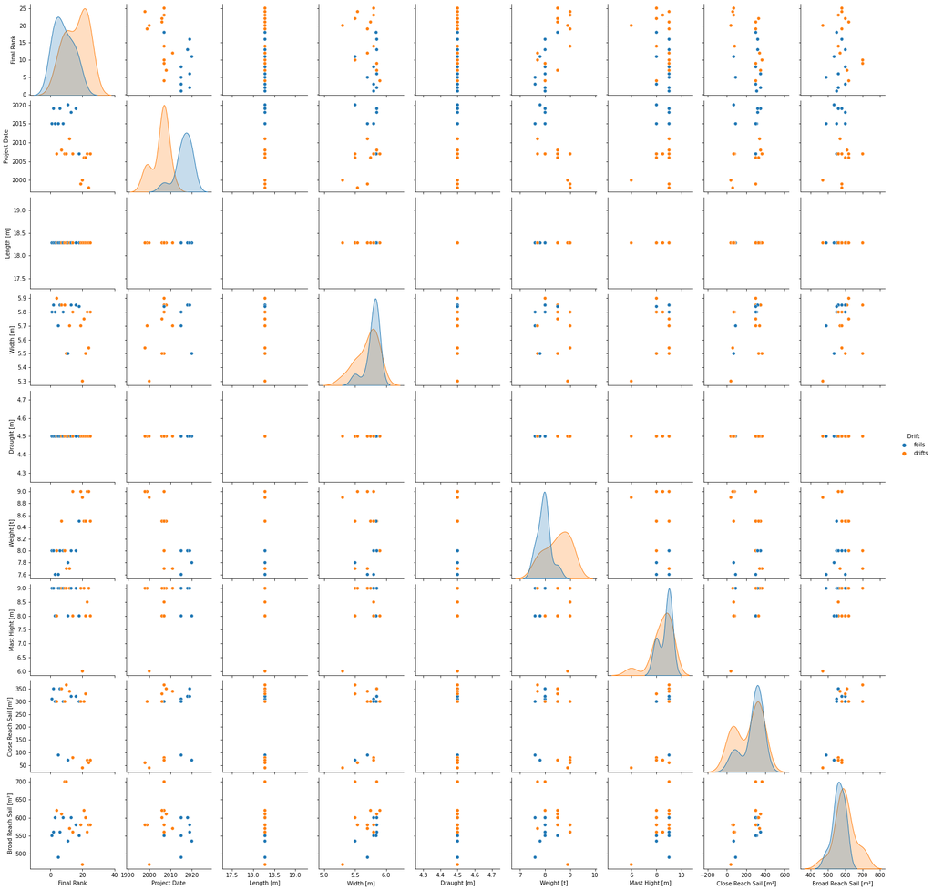

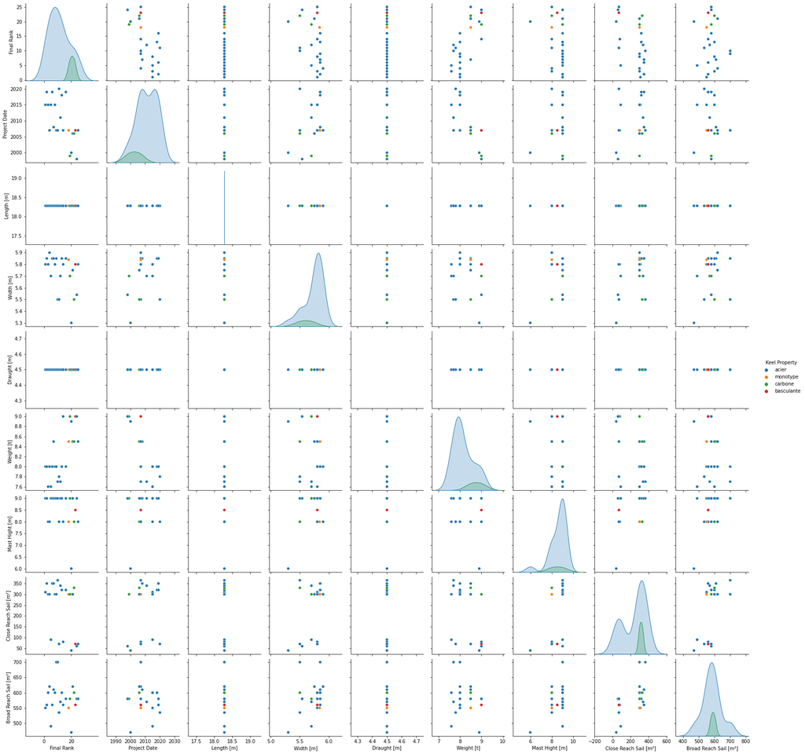

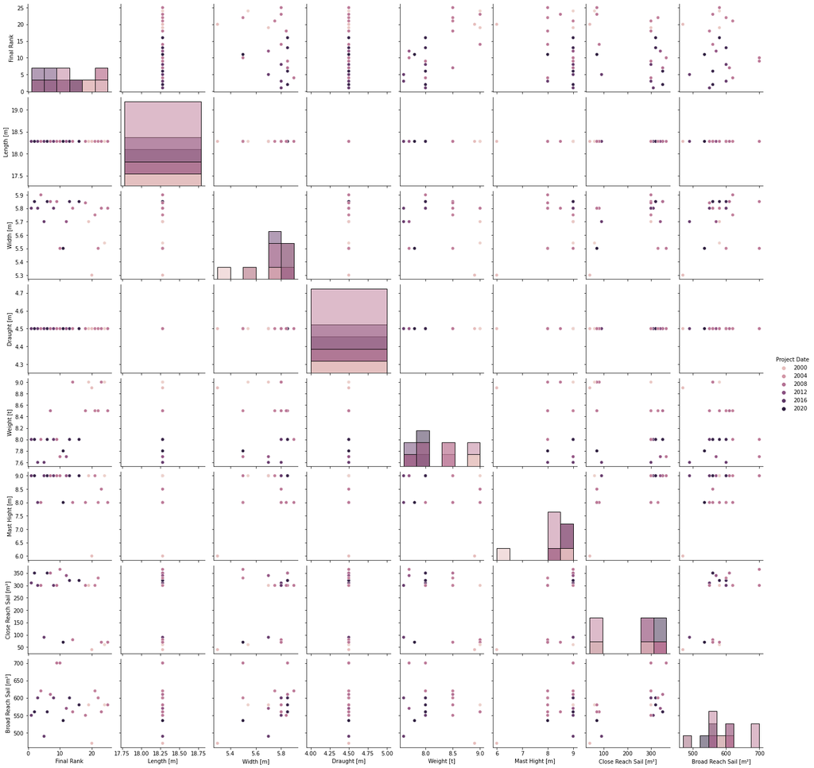

```python
fig1=sns.pairplot(DF_Merge2_Part, hue='Drift', kind='scatter', diag_kind='kde')
fig2=sns.pairplot(DF_Merge2_Part, hue='Keel Property', kind='scatter', diag_kind='kde')
fig3=sns.pairplot(DF_Merge2_Part, hue='Project Date', kind='scatter', diag_kind='hist')
```

## 3.2. Corrélation entre le classement et la VMG (non terminé)

### 3.2.1. 30min

```python
VMG_RLR = pd.DataFrame(DF_DailyRankCleaned.groupby('Rank')['Last30mn VMG [kts]'].mean())
Rank = VMG_RLR.index.values.reshape(-1,1)

linreg = LinearRegression(fit_intercept=True)
linreg.fit(Rank, VMG_RLR)
VMG_pred = linreg.predict(Rank)

Theta1 = np.round(linreg.coef_[0],4)
Theta0 = np.round(linreg.intercept_,4)
CoefDet = np.round(sklearn.metrics.r2_score(VMG_RLR, VMG_pred),4)

print("Correlation entre le rang et la vitesse VMG depuis le dernier classement:\n\n\
- Theta1 : {}\n\
- Theta0 : {}\n\
- CoefDet R2 : {}\n"\
      .format(Theta1, Theta0, CoefDet))

#sns.regplot(x = Rank, y = VMG_RLR, data = VMG_RLR)
```

```
Correlation entre le rang et la vitesse VMG depuis le dernier classement:

- Theta1 : [-0.1951]
- Theta0 : [13.1391]
- CoefDet R2 : 0.5888
```

[figure not shown]

```python
plt.scatter(Rank,VMG_RLR)
plt.xlabel("VMG")
plt.ylabel("Rank")
plt.title("Scatter Rank/VMG")
```

## 3.3. Distance parcourue par voilier

[figure not shown]

```python
plt.figure(dpi=150)
fig.suptitle('Distance parcourue/Temps')
legend={}
for i in DF_Final_Rank_Cleaned.index:
    plt.plot(DF_Merge1.loc[i,'Date_Time'],DF_Merge1.loc[i,'Last24h Distance [nm]'].cumsum(), label = i)
plt.xlabel("Time")
plt.ylabel("Distance [nm]")
plt.legend()
```